# dsu-technical-assessment

```python
# This Python 3 environment comes with many helpful analytics libraries installed
# It is defined by the kaggle/python Docker image: https://github.com/kaggle/docker-python
# For example, here's several helpful packages to load

import numpy as np # linear algebra
import pandas as pd # data processing, CSV file I/O (e.g. pd.read_csv)

# Input data files are available in the read-only "../input/" directory
# For example, running this (by clicking run or pressing Shift+Enter) will list all files under the input directory

import os
for dirname, _, filenames in os.walk('/kaggle/input'):
    for filename in filenames:
        print(os.path.join(dirname, filename))

# You can write up to 20GB to the current directory (/kaggle/working/) that gets preserved as output when you create a version using "Save & Run All"
# You can also write temporary files to /kaggle/temp/, but they won't be saved outside of the current session
```

```
/kaggle/input/student-attitude-and-behavior/Student Attitude and Behavior (Final).csv
```

**Description**: Whether you’re grinding for your week three midterm or standing on business while juggling everything else in life, being a student is a mix of stress, hustle, and (hopefully) some fun! We’ve provided you with a dataset of students’ academic performances, including information on their hobbies, extracurriculars, and study habits to help you dive deeper into the factors that impact student success.

```python
df = pd.read_csv("/kaggle/input/student-attitude-and-behavior/Student Attitude and Behavior (Final).csv")
```

```python
df.head()
```

|  | Student_ID | Gender | Height_cm | Weight_kg | Eleventh_Grade_GPA | Twelfth_Grade_GPA | College_GPA | Certification_Course | Hobbies | Daily_Study_Time_mins | Preferred_Study_Time | Salary_Expectation | Likes_Degree | Social_Media_Use_mins | Commute_Time_mins | Stress_Level | Financial_Status | Part_Time_Job | Average_GPA |
| --- | --- | --- | --- | --- | --- | --- | --- | --- | --- | --- | --- | --- | --- | --- | --- | --- | --- | --- | --- |
| 0 | 1 | Male | 100.0 | 58.0 | 3.224490 | 2.723404 | 3.20 | No | Video Games | 188.015592 | Morning | 40000 | No | 95 | 13.846239 | 2 | 2 | No | 3.049298 |
| 1 | 2 | Female | 90.0 | 40.0 | 2.857143 | 3.404255 | 2.80 | No | Cinema | 136.774800 | Morning | 15000 | Yes | 65 | 49.567665 | 2 | 2 | No | 3.020466 |
| 2 | 3 | Male | 159.0 | 78.0 | 2.897959 | 2.595745 | 2.20 | Yes | Cinema | 124.784457 | No preference | 13000 | Yes | 140 | 22.678964 | 1 | 2 | No | 2.564568 |
| 3 | 4 | Female | 147.0 | 20.0 | 2.857143 | 2.510638 | 2.32 | Yes | Reading books | 11.099660 | No preference | 1500000 | No | 90 | 88.312123 | 2 | 3 | No | 2.562594 |
| 4 | 5 | Male | 170.0 | 54.0 | 1.632653 | 2.765957 | 1.20 | No | Video Games | 30.000000 | Morning | 50000 | Yes | 115 | 145.197910 | 3 | 3 | No | 1.866204 |

## 1. How many students prefer to study at night?

```python
# see the unique values of study times
df['Preferred_Study_Time'].unique()
```

```
array(['Morning', 'No preference', 'Night'], dtype=object)
```

```python
night_study = df[df['Preferred_Study_Time'] == 'Night'].shape[0]
print(night_study, "students prefer to study at night.")
```

```
47 students prefer to study at night.
```

## 2. What percentage of students spend at least 90 minutes on social media and work a part time job? Please provide your answer rounded to three decimal places.

```python
ratio = df[(df['Social_Media_Use_mins'] >= 90) & (df['Part_Time_Job'] == 'Yes')].shape[0] / (df.shape[0])
percentage = round(ratio * 100, 3)
print(percentage, end = '')
print('% of students spend at least 90 min on social media and work a part time job.')
```

```
5.532% of students spend at least 90 min on social media and work a part time job.
```

## 3. Which hobby is associated with the lowest average stress levels among students? Please provide the hobby and the associated average stress level rounded to three decimal places.

```python
# group each hobby by its respective average stress level
hobbies_by_stress_df = df.groupby('Hobbies')['Stress_Level'].mean().reset_index()
# extract the minimum stress level and its corresponding hobby
min_row = hobbies_by_stress_df[hobbies_by_stress_df['Stress_Level'] == hobbies_by_stress_df['Stress_Level'].min()]
min_hobby = min_row['Hobbies'].values[0]
min_stress_level = round(min_row['Stress_Level'].values[0], 3)

print(f"The hobby with the lowest average stress level of {min_stress_level} is {min_hobby}.")
```

[output not shown]

## 4. What student had the highest median GPA across 11th grade, 12th grade, and college? Please provide the student's ID number and their median GPA rounded to three decimal places.

```python
# calculate median GPA across 11th grade, 12th grade, and college
df['median_GPA'] = df[['Eleventh_Grade_GPA', 'Twelfth_Grade_GPA', 'College_GPA']].median(axis=1)

# find the row with the highest median GPA
highest_median = df[df['median_GPA'] == df['median_GPA'].max()]

# extract the student ID and the highest median GPA
student_id = highest_median['Student_ID'].values[0]
max_median_gpa = round(highest_median['median_GPA'].values[0], 3)

print(f"The student with the highest median GPA is ID {student_id} with a median GPA of {max_median_gpa}.")
```

```
The student with the highest median GPA is ID 225 with a median GPA of 3.959.
```

# Optional Questions

## 1. Your friend who commutes from Pasadena to UCLA often blames the long drive for their tanking GPA. As a skeptical data scientist, this compels you to investigate whether there truly exists a relationship between commute time and academic performance. Formulate a claim on this possible relationship and analyze any trends or patterns in the data that would support your claim. Be sure to discuss any limitations or factors in the dataset that may affect the validity of your results.

**Claim**: Longer commute times are negatively associated with the GPAs of UCLA students.

```python
df.columns
```

```
Index(['Student_ID', 'Gender', 'Height_cm', 'Weight_kg', 'Eleventh_Grade_GPA',
       'Twelfth_Grade_GPA', 'College_GPA', 'Certification_Course', 'Hobbies',
       'Daily_Study_Time_mins', 'Preferred_Study_Time', 'Salary_Expectation',
       'Likes_Degree', 'Social_Media_Use_mins', 'Commute_Time_mins',
       'Stress_Level', 'Financial_Status', 'Part_Time_Job', 'Average_GPA',
       'median_GPA'],
      dtype='object')
```

We want to examine the correlation between 'Commute_Time_mins' and 'College_GPA'.

1. Visualize the data using scatter plots to observe the relationship between commute time and GPA.

```python
import matplotlib.pyplot as plt
import seaborn as sns
```

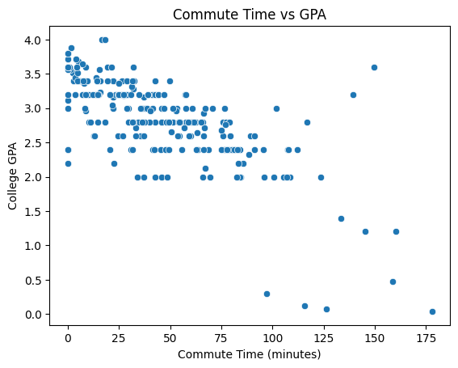

```python
sns.scatterplot(x='Commute_Time_mins', y='College_GPA', data=df)
plt.title('Commute Time vs GPA')
plt.xlabel('Commute Time (minutes)')
plt.ylabel('College GPA')
plt.show()
```

The graph of Commute Time (minutes) vs College GPA displays a **negative** correlation. This means that greater commute times are negatively correlated with college GPAs, however there exist certain confounding variables in the dataset that could impact this conclusion.

## 2. Many people say that "cash is king" and believe that having a higher economic status is associated with better outcomes in one's academic, professional, and personal life. To what degree, if any, does the data support this ideology? Use evidence from the dataset to build your answer. Make sure to thoroughly explain your reasoning and note any potential drawbacks to your approach.

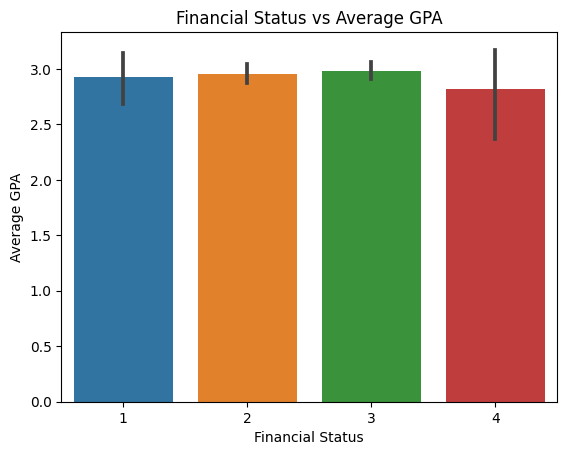

```python
sns.barplot(x='Financial_Status', y='Average_GPA', data=df)
plt.title('Financial Status vs Average GPA')
plt.xlabel('Financial Status')
plt.ylabel('Average GPA')
plt.show()
```

The barplot of Financial Status vs Average GPA shows a relatively uniform distribution, with a slightly lower average GPA for the students who consider themselves to be '4' on the financial status level. This conveys the notion that financial status does not have a significant effect on students' high school and college GPAs, and if anything, it could have a slight negative effect. Thus, the data does not support the theory that higher economic status is associated with better outcomes in one's academic life.

This uniform distribution could mean that GPAs are influenced by other factors that may or not be in the dataset, such as whether the student likes their major, whether they have a part time job, etc.

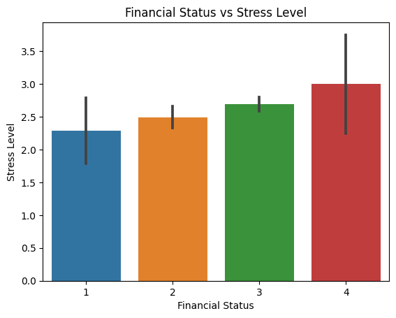

```python
sns.barplot(x='Financial_Status', y='Stress_Level', data=df)
plt.title('Financial Status vs Stress Level')
plt.xlabel('Financial Status')
plt.ylabel('Stress Level')
plt.show()
```

The higher levels of stress amongst the financially well-off students may stem from other factors, such as pressure from parents, higher expectations to maintain, competitive environments/mindsets, or the additional responsibility that comes with managing wealth.

To conclude, the data suggests that higher financial status can increase stress, challenging the notion that wealth inherently leads to a better or less stressful personal life. The evidence does not strongly suggest a correlation between wealth and academic performance.

### Limiting Factors:

- **self-reported**: Since this data was self-reported by students, there may be bias in how students interpret their own financial status and stress level. This can result in either an over or under estimate of correlation between financial status and personal well-being.
- **confounding variables**: There are several confounding variables that could have a potential effect on students' academic, professional, and personal well-being that were not taken into consideration, such as their study habits, family situation, quality of life, etc.